# Getting to Know Your Incomplete Data

## Preface

### R packages

In this practical, a number of R packages are used. If any of them are not installed you may be able to follow the practical but will not be able to run all of the code. The packages used (with versions that were used to generate the solutions) are:

- R version 3.6.0 (2019-04-26)
- `mice` (version: 3.4.0)
- `visdat` (version: 0.5.3)
- `JointAI` (version: 0.5.1)
- `VIM` (version: 4.8.0)
- `plyr` (version: 1.8.4)
- `corrplot` (version: 0.84)
- `ggplot2` (version: 3.1.1)

### Help files

You can find help files for any function by adding a `?` before the name of the function.

Alternatively, you can look up the help pages online at https://www.rdocumentation.org/ or find the whole manual for a package at https://cran.r-project.org/web/packages/available_packages_by_name.html

## Dataset

### Overview

For this example, we will use the **NHANES** dataset. To get the **NHANES** data, load the file `NHANES_for_practicals.RData`. You can download it [here](https://nerler.github.io/EP16_Multiple_Imputation/practical/data/index.html). To load this dataset into R, you can use the command `file.choose()` which opens the explorer and allows you to navigate to the location of the file on your computer. If you know the path to the file, you can also use `load("<path>/NHANES_for_practicals.RData")`.

#### Task

Let’s take a first look at the data. Useful functions are `dim()`, `head()`, `str()` and `summary()`.

#### Solution

```r
dim(NHANES)
```

```
## [1] 1000   24
```

```r
head(NHANES)
```

|  | HDL | race | DBP | bili | smoke | DM | gender | WC | chol | HyperMed | alc | SBP | wgt | hypten | cohort | occup | age | educ | albu | creat | uricacid | BMI | hypchol | hgt |
| --- | --- | --- | --- | --- | --- | --- | --- | --- | --- | --- | --- | --- | --- | --- | --- | --- | --- | --- | --- | --- | --- | --- | --- | --- |
| 858 | 1.58 | Other Hispanic | 56.66667 | 0.5 | never | no | female | 64.5 | 4.29 | NA | <=1 | 104.6667 | 46.26642 | no | 2011 | working | 22 | some college | 3.8 | 0.61 | 3.6 | 19.27253 | no | 1.5494 |
| 103 | 1.24 | other | 81.33333 | 0.9 | never | no | male | 81.4 | 4.27 | NA | NA | 124.6667 | 63.50293 | no | 2011 | working | 39 | College or above | 4.3 | 0.87 | 5.4 | 19.52584 | no | 1.8034 |
| 338 | 1.71 | Non-Hispanic White | 70.00000 | 0.7 | current | no | male | 76.0 | 4.22 | NA | NA | 133.3333 | 62.14215 | no | 2011 | working | 51 | College or above | 4.3 | 0.89 | 6.2 | 22.11215 | no | 1.6764 |
| 344 | 1.01 | Non-Hispanic White | 66.00000 | 0.4 | never | no | female | 139.5 | 3.96 | NA | <=1 | 141.3333 | 113.85168 | yes | 2011 | working | 45 | College or above | 3.6 | 0.61 | 4.3 | 41.76816 | no | 1.6510 |
| 2382 | 1.09 | Non-Hispanic White | 69.33333 | 0.9 | current | no | male | 94.6 | 4.97 | NA | 3-7 | 117.3333 | 102.05828 | no | 2011 | working | 31 | High school graduate | 4.9 | 0.83 | 6.1 | 32.28381 | no | 1.7780 |
| 2479 | NA | Non-Hispanic White | 71.33333 | NA | former | no | female | 101.8 | NA | yes | 0 | 148.0000 | 70.30682 | yes | 2011 | not working | 75 | Less than 9th grade | NA | NA | NA | 24.27618 | NA | 1.7018 |

```r
str(NHANES)
```

```
## 'data.frame':    1000 obs. of  24 variables:
##  $ HDL     : num  1.58 1.24 1.71 1.01 1.09 NA NA 1.16 1.16 1.5 ...
##  $ race    : Factor w/ 5 levels "Mexican American",..: 2 5 3 3 3 3 2 3 1 3 ...
##  $ DBP     : num  56.7 81.3 70 66 69.3 ...
##  $ bili    : num  0.5 0.9 0.7 0.4 0.9 NA NA 0.9 0.6 0.9 ...
##  $ smoke   : Ord.factor w/ 3 levels "never"<"former"<..: 1 1 3 1 3 2 1 2 2 3 ...
##  $ DM      : Factor w/ 2 levels "no","yes": 1 1 1 1 1 1 2 1 1 1 ...
##  $ gender  : Factor w/ 2 levels "male","female": 2 1 1 2 1 2 1 1 1 1 ...
##  $ WC      : num  64.5 81.4 76 139.5 94.6 ...
##  $ chol    : num  4.29 4.27 4.22 3.96 4.97 NA NA 5.2 5.56 4.86 ...
##  $ HyperMed: Ord.factor w/ 3 levels "no"<"previous"<..: NA NA NA NA NA 3 3 NA NA NA ...
##  $ alc     : Ord.factor w/ 5 levels "0"<"<=1"<"1-3"<..: 2 NA NA 2 4 1 1 5 3 4 ...
##  $ SBP     : num  105 125 133 141 117 ...
##  $ wgt     : num  46.3 63.5 62.1 113.9 102.1 ...
##  $ hypten  : Factor w/ 2 levels "no","yes": 1 1 1 2 1 2 2 1 1 1 ...
##  $ cohort  : chr  "2011" "2011" "2011" "2011" ...
##  $ occup   : Factor w/ 3 levels "working","looking for work",..: 1 1 1 1 1 3 3 1 1 1 ...
##  $ age     : num  22 39 51 45 31 75 73 52 29 40 ...
##  $ educ    : Factor w/ 5 levels "Less than 9th grade",..: 4 5 5 5 3 1 2 4 3 1 ...
##  $ albu    : num  3.8 4.3 4.3 3.6 4.9 NA NA 3.9 4.9 4.3 ...
##  $ creat   : num  0.61 0.87 0.89 0.61 0.83 NA NA 0.91 0.93 0.94 ...
##  $ uricacid: num  3.6 5.4 6.2 4.3 6.1 NA NA 7.8 3.9 4.9 ...
##  $ BMI     : num  19.3 19.5 22.1 41.8 32.3 ...
##  $ hypchol : Factor w/ 2 levels "no","yes": 1 1 1 1 1 NA NA 1 1 1 ...
##  $ hgt     : num  1.55 1.8 1.68 1.65 1.78 ...
```

```r
summary(NHANES)
```

```
##       HDL                        race          DBP              bili            smoke       DM
##  Min.   :0.360   Mexican American  :112   Min.   : 12.67   Min.   :0.2000   never  :608   no :853
##  1st Qu.:1.110   Other Hispanic    :110   1st Qu.: 64.00   1st Qu.:0.6000   former :191   yes:147
##  Median :1.320   Non-Hispanic White:350   Median : 70.67   Median :0.7000   current:199
##  Mean   :1.391   Non-Hispanic Black:229   Mean   : 70.80   Mean   :0.7527   NA's   :  2
##  3rd Qu.:1.580   other             :199   3rd Qu.: 77.33   3rd Qu.:0.9000
##  Max.   :4.030                            Max.   :130.00   Max.   :2.9000
##  NA's   :86                               NA's   :59       NA's   :95
##     gender          WC              chol            HyperMed     alc           SBP
##  male  :493   Min.   : 61.90   Min.   : 2.070   no      : 25   0   :113   Min.   : 81.33
##  female:507   1st Qu.: 85.00   1st Qu.: 4.270   previous: 20   <=1 :281   1st Qu.:109.33
##               Median : 95.10   Median : 4.910   yes     :142   1-3 :105   Median :118.00
##               Mean   : 96.35   Mean   : 4.998   NA's    :813   3-7 : 81   Mean   :120.15
##               3rd Qu.:105.50   3rd Qu.: 5.610                  >7  :101   3rd Qu.:128.67
##               Max.   :154.70   Max.   :10.680                  NA's:319   Max.   :202.00
##               NA's   :49       NA's   :86                                 NA's   :59
##       wgt          hypten       cohort                       occup          age
##  Min.   : 39.01   no  :693   Length:1000        working         :544   Min.   :20.00
##  1st Qu.: 63.50   yes :265   Class :character   looking for work: 46   1st Qu.:31.00
##  Median : 76.88   NA's: 42   Mode  :character   not working     :393   Median :43.00
##  Mean   : 78.35                                 NA's            : 17   Mean   :45.23
##  3rd Qu.: 89.13                                                        3rd Qu.:59.00
##  Max.   :167.83                                                        Max.   :79.00
##  NA's   :22
##                    educ          albu           creat           uricacid          BMI
##  Less than 9th grade : 83   Min.   :3.000   Min.   :0.4400   Min.   :2.300   Min.   :15.34
##  9-11th grade        :133   1st Qu.:4.100   1st Qu.:0.6900   1st Qu.:4.400   1st Qu.:23.18
##  High school graduate:228   Median :4.300   Median :0.8200   Median :5.300   Median :26.58
##  some college        :283   Mean   :4.289   Mean   :0.8525   Mean   :5.356   Mean   :27.49
##  College or above    :272   3rd Qu.:4.500   3rd Qu.:0.9500   3rd Qu.:6.200   3rd Qu.:30.73
##  NA's                :  1   Max.   :5.400   Max.   :7.4600   Max.   :9.900   Max.   :60.54
##                             NA's   :91      NA's   :91       NA's   :92      NA's   :37
##  hypchol         hgt
##  no  :813   Min.   :1.397
##  yes :101   1st Qu.:1.626
##  NA's: 86   Median :1.676
##             Mean   :1.685
##             3rd Qu.:1.753
##             Max.   :1.981
##             NA's   :22
```

### Variable coding

It is important to check that all variables are coded correctly, i.e., have the correct `class`. Imputation software (e.g., the **mice** package) uses the `class` to automatically select imputation methods. When importing data from other software it can happen that factors become continuous variables or that ordered factors lose their ordering.

`str()` showed that in the NHANES data `smoke` and `alc` are correctly specified as ordinal variables, but `educ` is an unordered factor.

#### Task

Using `levels(NHANES$educ)` we can print the names of the categories of `educ`. Convert the unordered factor to an ordered factor, for example using `as.ordered()`. Afterwards, check if the conversion was successful.

#### Solution

```r
levels(NHANES$educ)
```

```
## [1] "Less than 9th grade"  "9-11th grade"         "High school graduate" "some college"
## [5] "College or above"
```

```r
NHANES$educ <- as.ordered(NHANES$educ)

str(NHANES$educ)
```

```
##  Ord.factor w/ 5 levels "Less than 9th grade"<..: 4 5 5 5 3 1 2 4 3 1 ...
```

## Distribution of missing values

### Missing data pattern

In the `summary()` we could already see that there are missing values in several variables. The missing data pattern can be obtained and visualized by several functions from different packages. Examples are

- `md.pattern()` from package **mice**
- `md_pattern()` from package **JointAI** (with argument `patter = TRUE`)
- `aggr()` from package **VIM**
- `vis_dat()` and `vis_miss()` from package **visdat**

#### Task

Explore the missing data pattern of the NHANES data.

#### Solution (i)

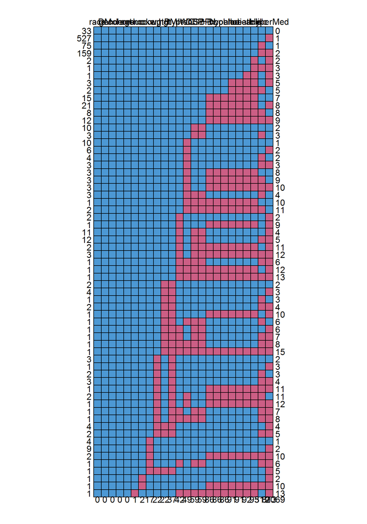

```r
mdp <- mice::md.pattern(NHANES)
```

```r
mdp
```

```
##     race DM gender cohort age educ smoke occup wgt hgt BMI hypten WC DBP SBP HDL chol hypchol albu
## 33     1  1      1      1   1    1     1     1   1   1   1      1  1   1   1   1    1       1    1
## 527    1  1      1      1   1    1     1     1   1   1   1      1  1   1   1   1    1       1    1
## 75     1  1      1      1   1    1     1     1   1   1   1      1  1   1   1   1    1       1    1
## 159    1  1      1      1   1    1     1     1   1   1   1      1  1   1   1   1    1       1    1
## 2      1  1      1      1   1    1     1     1   1   1   1      1  1   1   1   1    1       1    1
## 1      1  1      1      1   1    1     1     1   1   1   1      1  1   1   1   1    1       1    1
## 1      1  1      1      1   1    1     1     1   1   1   1      1  1   1   1   1    1       1    1
## 3      1  1      1      1   1    1     1     1   1   1   1      1  1   1   1   1    1       1    0
## 2      1  1      1      1   1    1     1     1   1   1   1      1  1   1   1   1    1       1    0
## 15     1  1      1      1   1    1     1     1   1   1   1      1  1   1   1   0    0       0    0
## 21     1  1      1      1   1    1     1     1   1   1   1      1  1   1   1   0    0       0    0
## 8      1  1      1      1   1    1     1     1   1   1   1      1  1   1   1   0    0       0    0
## 12     1  1      1      1   1    1     1     1   1   1   1      1  1   1   1   0    0       0    0
## 10     1  1      1      1   1    1     1     1   1   1   1      1  1   0   0   1    1       1    1
```

[output cut: 115 more lines]

`md.pattern()` from package **mice** gives us a matrix where each row represents one missing data pattern (1 = observed, 0 = missing). The rownames show how many rows of the dataset have the given pattern. The last column shows the number of missing values in each pattern, the last row the number of missing values per variable.

`md.pattern()` also plots the missing data pattern automatically.

#### Solution (ii)

```r
MDP <- JointAI::md_pattern(NHANES, pattern = TRUE)
```

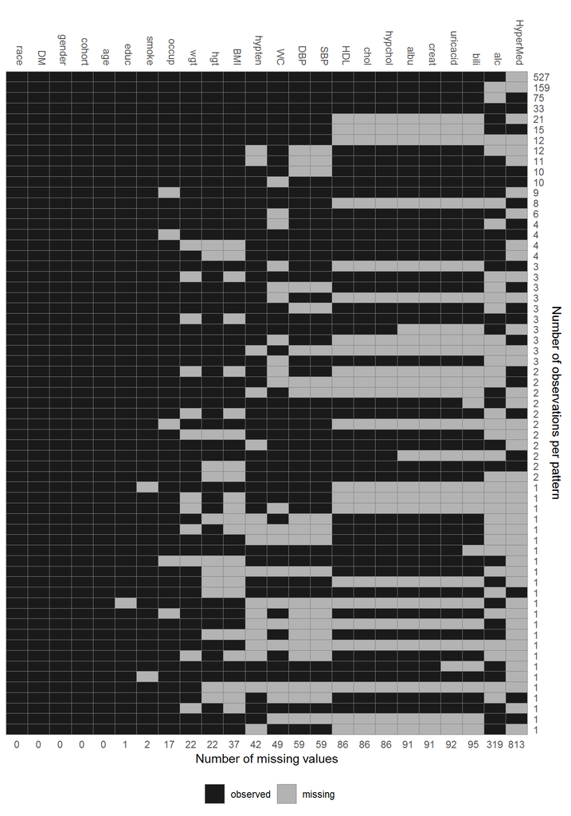

```r
MDP
```

```
##      race DM gender cohort age educ smoke occup wgt hgt BMI hypten WC DBP SBP HDL chol hypchol albu
## 1       1  1      1      1   1    1     1     1   1   1   1      1  1   1   1   1    1       1    1
## 2       1  1      1      1   1    1     1     1   1   1   1      1  1   1   1   1    1       1    1
## 3       1  1      1      1   1    1     1     1   1   1   1      1  1   1   1   1    1       1    1
## 4       1  1      1      1   1    1     1     1   1   1   1      1  1   1   1   1    1       1    1
## 5       1  1      1      1   1    1     1     1   1   1   1      1  1   1   1   0    0       0    0
## 6       1  1      1      1   1    1     1     1   1   1   1      1  1   1   1   0    0       0    0
## 7       1  1      1      1   1    1     1     1   1   1   1      1  1   1   1   0    0       0    0
## 8       1  1      1      1   1    1     1     1   1   1   1      0  1   0   0   1    1       1    1
## 9       1  1      1      1   1    1     1     1   1   1   1      0  1   0   0   1    1       1    1
## 10      1  1      1      1   1    1     1     1   1   1   1      1  1   0   0   1    1       1    1
## 11      1  1      1      1   1    1     1     1   1   1   1      1  0   1   1   1    1       1    1
## 12      1  1      1      1   1    1     1     0   1   1   1      1  1   1   1   1    1       1    1
## 13      1  1      1      1   1    1     1     1   1   1   1      1  1   1   1   0    0       0    0
## 14      1  1      1      1   1    1     1     1   1   1   1      1  0   1   1   1    1       1    1
```

[output cut: 115 more lines]

The function `md_pattern()` from package **JointAI** gives a matrix very similar to the one obtained from `mice::md.pattern()`. However, here, the number of rows in the data that have a particular missing data pattern are given in the last column.

For more information on how to customize the visualization by `md_pattern()` see the vignette [Visualizing Incomplete Data](https://nerler.github.io/JointAI/articles/VisualizingIncompleteData.html) on the [webpage of **JointAI**](https://nerler.github.io/JointAI/index.html).

#### Solution (iii)

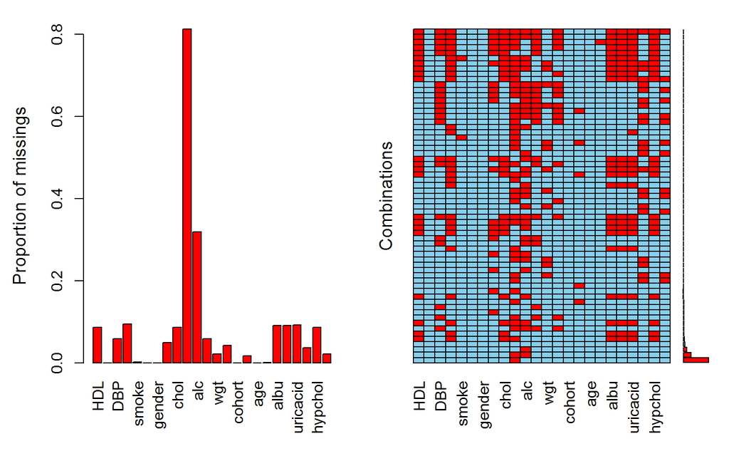

```r
VIM::aggr(NHANES)
```

`aggr()` from **VIM** plots a histogram of the proportion of missing values per column as well as a visualization of the missing data pattern. Here, a small histogram on the right edge of the plot shows the proportion of cases in each pattern.

For more options how to customize the plot, see the [**VIM** documentation](https://CRAN.R-project.org/package=VIM).

### Proportion of missing values

#### Task

Now get an overview of

- how much missingness there is in each variable, and
- the proportion of (in)complete cases.

The function `complete.cases()` will give you a vector that is TRUE if the the case is complete and FALSE if there are missing values.

`is.na()` returns `TRUE` if the value is missing, `FALSE` if the value is observed

`colSums()` calculates the sum of values in each column of a data.frame or matrix

`colMeans()` calculates the mean of values in each column of a data.frame or matrix

#### Solution

```r
# number and proportion of complete cases
cbind(
  "#" = table(ifelse(complete.cases(NHANES), 'complete', 'incomplete')),
  "%" = round(100 * table(!complete.cases(NHANES))/nrow(NHANES), 2)
)
```

```
##              #    %
## complete    33  3.3
## incomplete 967 96.7
```

```r
# number and proportion of missing values per variable
cbind("# NA" = sort(colSums(is.na(NHANES))),
      "% NA" = round(sort(colMeans(is.na(NHANES))) * 100, 2))
```

```
##          # NA % NA
## race        0  0.0
## DM          0  0.0
## gender      0  0.0
## cohort      0  0.0
## age         0  0.0
## educ        1  0.1
## smoke       2  0.2
## occup      17  1.7
## wgt        22  2.2
## hgt        22  2.2
## BMI        37  3.7
## hypten     42  4.2
## WC         49  4.9
## DBP        59  5.9
## SBP        59  5.9
## HDL        86  8.6
## chol       86  8.6
## hypchol    86  8.6
## albu       91  9.1
## creat      91  9.1
## uricacid   92  9.2
## bili       95  9.5
## alc       319 31.9
## HyperMed  813 81.3
```

### Relationship between variables

In the missing data pattern we could already see that some variables tend to be missing together. But there may be different types of relationships between variables that are of interest.

#### Task 1

Our data contains `hgt` (height), `wgt` (weight) and `BMI`. Check the missing data pattern specifically for those three variables.

#### Solution 1

```r
# Three solutions to choose from:
JointAI::md_pattern(NHANES[, c("hgt", "wgt", "BMI")], pattern = TRUE, plot = FALSE)
```

```
##      hgt wgt BMI Npat
## 1      1   1   1  963
## 2      1   0   0   15
## 3      0   1   0   15
## 4      0   0   0    7
## Nmis  22  22  37   81
```

```r
with(NHANES,
     table(ifelse(is.na(hgt), 'height mis.', 'height obs.'),
           ifelse(is.na(wgt), 'weight mis.', 'weight obs.'),
           ifelse(is.na(BMI), 'BMI mis.', 'BMI obs.'))
)
```

```
## , ,  = BMI mis.
##
##
##               weight mis. weight obs.
##   height mis.           7          15
##   height obs.          15           0
##
## , ,  = BMI obs.
##
##
##               weight mis. weight obs.
##   height mis.           0           0
##   height obs.           0         963
```

```r
plyr::ddply(NHANES, c(height = "ifelse(is.na(hgt), 'missing', 'observed')",
                      weight = "ifelse(is.na(wgt), 'missing', 'observed')",
                      BMI = "ifelse(is.na(BMI), 'missing', 'observed')"),
            plyr::summarize,
            N = length(hgt)
)
```

| height | weight | BMI | N |
| --- | --- | --- | --- |
| missing | missing | missing | 7 |
| missing | observed | missing | 15 |
| observed | missing | missing | 15 |
| observed | observed | observed | 963 |

As we have already seen in the lecture, there are some cases where only either `hgt` or `wgt` is missing. `BMI` is only observed when both components are observed. To use all available information, we want to impute `hgt` and `wgt` separately and calculate `BMI` from the imputed values.

#### Task 2

The data contains variables on hypertension (`hypten`) and the use of medication to treat hypertension (`HyperMed`). We might expect that medication is only prescribed for patients with hypertension, hence, we need to investigate the relationship between `HyperMed` and `hypten`.

- Make a table of the two variables to confirm our expectation.
- Make sure that missing values are also displayed in that table!

#### Solution 2

```r
with(NHANES, table(HyperMed, hypten, exclude = NULL))
```

```
##           hypten
## HyperMed    no yes <NA>
##   no         0  25    0
##   previous   0  20    0
##   yes        0 142    0
##   <NA>     693  78   42
```

#### Task 3

Furthermore, we can expect a systematic relationship between the variables `hypchol` (hypercholesterolemia) and `chol` (serum cholesterol). Find out how these two variables are related.

#### Solution 3

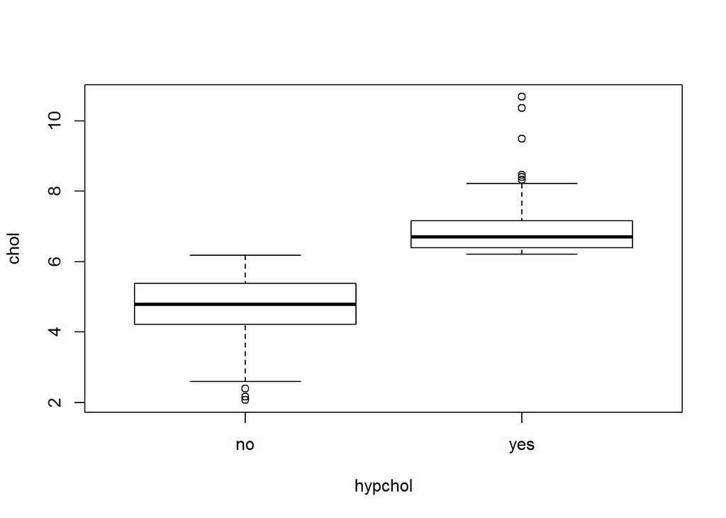

```r
with(NHANES, plot(chol ~ hypchol))
```

```r
with(NHANES, summary(chol[hypchol == "no"]))
```

```
##    Min. 1st Qu.  Median    Mean 3rd Qu.    Max.    NA's
##   2.070   4.220   4.780   4.755   5.380   6.180      86
```

```r
with(NHANES, summary(chol[hypchol == "yes"]))
```

```
##    Min. 1st Qu.  Median    Mean 3rd Qu.    Max.    NA's
##    6.21    6.39    6.70    6.95    7.16   10.68      86
```

It seems that `hypchol` is defined as `chol > 6.2`, which makes `hypchol` dependent on `chol`.

#### Task 4

Visualize the correlations between variables to detect associations that you may have missed.

#### Solution 4

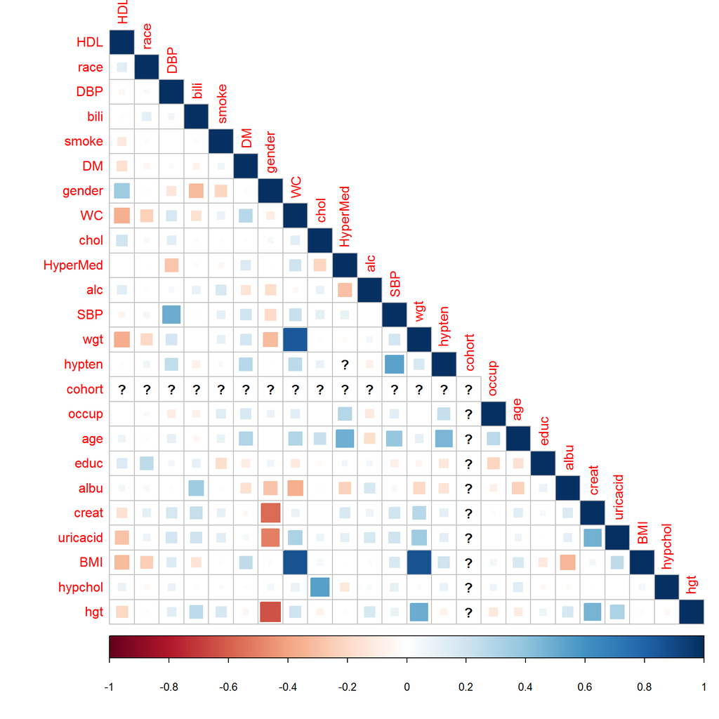

```r
# convert all variables to numeric
dat_num <- sapply(NHANES, as.numeric)
cormat <- cor(dat_num, use = 'pair', method = 'spearman')
corrplot::corrplot(cormat, method = 'square', type = 'lower')
```

**Note:** Correlations involving categorical variables are not usually done! We only use this as a quick-and-dirty method for visualization of relationships.

The question marks in the plot indicate that no correlation could be calculated for `cohort` (because `cohort` is the same for all subjects) and neither between `HyperMed` and `hypten` (but we already knew that).

```r
with(NHANES, table(ifelse(is.na(WC), 'WC mis.', 'WC obs.'),
                   ifelse(is.na(wgt), 'wgt mis.', 'wgt obs.')
))
```

```
##
##           wgt mis. wgt obs.
##   WC mis.        4       45
##   WC obs.       18      933
```

## Distribution of the data

Before imputing missing values it is important to take a look at how the observed parts of incomplete variables are distributed, so that we can choose appropriate imputation models.

### Task

Visualize the distributions of the incomplete continuous and categorical variables. The package **JointAI** provides the convenient function `plot_all()`,

Pay attention to

- whether continuous distributions deviate considerably from the normal distribution,
- if variables have values close to the limits of the range they are defined in,
- whether categorical variables are very unbalanced (i.e., some category very small).

### Solution

```r
par(mar = c(3, 3, 2, 1), mgp = c(2, 0.6, 0))
JointAI::plot_all(NHANES, nclass = 30, ncol = 4)
```

[figure not shown]

To learn more about additional options of `plot_all()` check out the vignette [Visualizing Incomplete Data](https://nerler.github.io/JointAI/articles/VisualizingIncompleteData.html) on the [webpage of **JointAI**](https://nerler.github.io/JointAI/index.html).

© Nicole Erler